# Doing Data Science - section 403 - Unit 3 - Live Assignment #3

Anne Francomano

May 27, 2018

## Question 1 -

GitHub Cloning (20 points): Using Git, clone the following GitHub repository to your local machine: https://github.com/caesar0301/awesome-public-datasets. In RMarkdown, please show the code (commented out, as it’s not R syntax) that you used to create a new directory, navigate to the appropriate directory, and clone the repository to it. Like actual Git, one command per line, please.

```
anne@lenovo-PC MINGW64 ~
$ mkdir git_repositories

anne@lenovo-PC MINGW64 ~
$ cd git_repositories

anne@lenovo-PC MINGW64 ~/git_repositories
$ mkdir Unit3SampleProject

anne@lenovo-PC MINGW64 ~/git_repositories
$ cd Unit3SampleProject

anne@lenovo-PC MINGW64 ~/git_repositories/Unit3SampleProject
$ echo "# An Example Repository" > README.md

anne@lenovo-PC MINGW64 ~/git_repositories/Unit3SampleProject
$ git init
Initialized empty Git repository in              C:/Users/anne/git_repositories/Unit3SampleProject/.git/

anne@lenovo-PC MINGW64 ~/git_repositories/Unit3SampleProject (master)
$ git add README.md

anne@lenovo-PC MINGW64 ~/git_repositories/Unit3SampleProject (master)
$ git clone https://github.com/caesar0301/awesome-public-datasets
Cloning into 'awesome-public-datasets'...
remote: Counting objects: 1475, done.
remote: Total 1475 (delta 0), reused 0 (delta 0), pack-reused 1475
Receiving objects: 100% (1475/1475), 561.47 KiB | 59.00 KiB/s, done.
Resolving deltas: 100% (860/860), done.

anne@lenovo-PC MINGW64 ~/git_repositories/Unit3SampleProject (master)
$ dir
awesome-public-datasets  README.md
```

## Question 2A + 2B + 2C: R Code and output below

Data Summary (20 points): From this aforementioned cloned repo, please extract titanic.csv.zip. To be clear, this does not have to be done in Git or command line.

1. In R, please read in titanic.csv via either read.table() or read.csv(), assigning it to df. This dataset follows the passengers aboard the Titanic, including their fees paid, rooms rented, and survivorship status.
2. Output the respective count of females and males aboard the Titanic. Plot the frequency of females and males. Be sure to give an accurate title and label the axes.
3. Please use one apply function (to review: swirl() modules 11, 12) to output the means of Age, Fare, and Survival. Make sure the output is a real number for all three means.

```r
# a. Set the working directory and read the titanic.csv file into R
setwd ("C:/Users/anne/git_repositories/Unit3SampleProject")
df <- read.csv("titanic.csv", header=TRUE)

# b. Counts of female and male passengers And plot frequency of each
df.sex <- table(df$Sex)
df.sex
```

```
##
## female   male
##    314    577
```

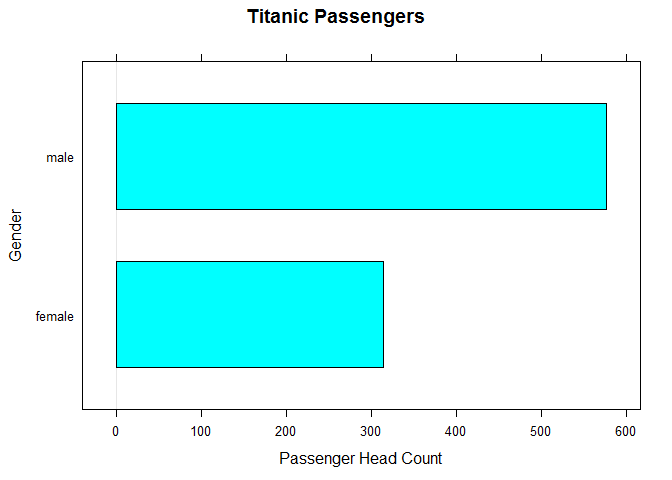

```r
library(lattice)
barchart(df.sex, main="Titanic Passengers", xlab="Passenger Head Count", ylab="Gender")
```

```r
# c. Use one apply function to output the means of Age, Fare, and Survival
#     Age column contains NAs ;  let's calculate the mean of the existing passenger age data
TheMeanAge <- mean(df$Age, na.rm=TRUE)
TheMeanAge
```

```
## [1] 29.69912
```

```r
#   Let's replace the missing data with mean of valid passenger age data
df$Age[is.na(df$Age)] = TheMeanAge
#   create a new dataframe with just the columns of interest and apply mean
df2 <- df[, c("Survived", "Age", "Fare")]
apply(df2, 2, mean)
```

```
##   Survived        Age       Fare
##  0.3838384 29.6991176 32.2042080
```

## Question 3A + 3B + 3C + 3D + 3E: R Code and output below

Function Building (30 points): You research sleep and just got your first data set. Later, you’ll have another dataset with the same column names, so you want to create a helper function that you can analyze this dataset and the next. Load sleep_data_01.csv (found at http://talklab.psy.gla.ac.uk/L1_labs/lab_1/homework/index.html).  
Questions 3A through 3D should be answered in function(x){}. 3E can be outside of the function.

1. Create objects for the median Age, the minimum and maximum Duration of sleep, and the mean and standard deviation of the Rosenberg Self Esteem scale (RSES). You may need to specify a few options like in Problem 2 and live session.
2. Create a data.frame object called report: it should consist of the median age, the RSES mean and standard deviation respectively divided by five (since there are five questions and these scores are summed), and the range of Duration (the statistical definition of range; it should be a single number.)
3. Change the column names of this data.frame to MedianAge, SelfEsteem, SE_SD, and DurationRange.
4. Round the report to at most 2 digits: leave this as the closing line to the function.
5. Finally, run the function on your sleep data to show the output.

```r
sleep_function <- function(dataset, questions) {
# a.
#   Address DATA CLEANUP first

#   AGE Column - Address NA in data
MeanAge <- mean(dataset$Age, na.rm=TRUE)        # find mean of non NA data
dataset$Age[is.na(dataset$Age)] = MeanAge       # replace NA with mean

#   DURATION Column - Address NA in data
MeanDur <- mean(dataset$Duration, na.rm=TRUE)   # find mean of non NA data
dataset$Duration[is.na(dataset$Duration)] = MeanDur     #replace NA with mean


#   RSES Column - Address NA in data
MeanRSES <- mean(dataset$RSES, na.rm=TRUE)          # find mean of non NA data
dataset$RSES[is.na(dataset$RSES)] = MeanRSES        # replace NA with mean


#  Now save calculations in the objects
MedAge <- median(dataset$Age)                 # get MEDIAN of AGE
MinDur <- min(dataset$Duration)             # get MIN of DURATION
MaxDur <- max(dataset$Duration)               # get MAX of DURATION
# now determine the RANGE of DURATION
RangeDur <- range(dataset$Duration) [2] - range(dataset$Duration) [1] + 1

MeanRSES <- mean(dataset$RSES)            # get MEAN of RSES
SdRSES  <-  sd(dataset$RSES)                # get STD Dev of RSES



# b. Create dataframe called report
report <- data.frame(MedAge, MeanRSES/questions, SdRSES/questions, RangeDur)

# c. Set new column names to MedianAge, SelfEsteem, SE_SD, and DurationRange.
colnames(report) = c("MedianAge", "SelfEsteem", "SE_SD", "DurationRange")

# d. Round the report values to 2 digits..
report <- round(report)
}

# e.Run the function:
#   first... read in the sleep data file of interest
sleepdata <- read.csv("sleep_data_01.csv", sep=",", header=TRUE)

#   second... set the number of questions
numquestions<- 5

#   third ... invoke the sleep_function for the sleep dataset of interest
my_report <- sleep_function(sleepdata, numquestions)

#   fourth ... display the function output
my_report
```

```
##   MedianAge SelfEsteem SE_SD DurationRange
## 1        14          4     1             8
```